# Illinois Traffic Data Analysis

Tiasia Saunders

2026-06-05

### Chicago Police Department versus other Illinois Law Enforcement Agencies Correlation with the Veil of Darkness

#### Is Racial Bias in Traffic Stops a Chicago Problem or a Statewide Problem?

- Using four years of Illinois traffic stop data from 2021 to 2024, I want to examine whether racial disparities in traffic stops extend beyond the Chicago Police Department to suburban and downstate Illinois law enforcement agencies. While CPD has faced significant scrutiny, especially since the fatal shooting of Dexter Reed, a 26-year-old Black man who was shot and killed in 2024 by the Chicago Police Department during a shootout between him and officers, smaller departments across Illinois operate with far less oversight and have received almost no data-driven accountability reporting. I would like to measure the racial disparity angle through using the veil of darkness lens.
- Veil of Darkness Explanation:
  - It is a statistical methodology, created by Jeffrey Grogger and Greg Ridgeway in 2006, that is used to test for racial bias in traffic stops
  - It compares daytime stops to nighttime stops, relying on the hypothesis that at nighttime, natural darkness masks a driver’s race, which prevents racially biased officers from profiling them
  - The theory: if racial profiling exists, there should be a higher percentage of minority drivers stopped during daylight hours when officers can easily identify race, compared to nighttime hours when the ‘veil of darkness’ conceals the person’s race
  - Daytime: 6 a.m. to 5 p.m.
  - Nighttime: 10 p.m. to 4 a.m.
  - Excluded Transition Hours: 4 a.m.–5:59 a.m. and 5 p.m.–9:59 p.m.
- Proposed Methodology:
  - Will be looking at the racial breakdown of traffic stops across all Illinois law enforcement agencies, including CPD, to determine if there is a racial disparity in who gets stopped the most.
  - Analysis will be done on traffic_24 (all other Illinois law enforcement agencies traffic enforcement data) and traffic_CPD_24 (Chicago Police Department traffic enforcement data) to determine if there is a racial disparity in both CPD and the other Illinois law enforcement agencies, and then comparing the two to see if there is a similar pattern in both data sets.
- Veil of Darkness: Will be determining racial bias through looking at the two sets of time ranges, the day and the night, to examine whether there is an obvious decrease in the amount of Black or brown people who are stopped at night due to the lack of visibility Suspicion Threshold: Will be looking at the resulting actions of stops after the initial traffic stop to determine whether there is a drastic disparity between how Black/brown versus white people are treated during a traffic stop
- Data Process Workflow:
- So, I have downloaded the 16 (four per year from 2021-2024) datasets into my .rmd file and have begun preliminary analysis on it to see what I am working with
- For the sake of time, I will be performing the analysis on just the 2024 traffic data.
- I have added the 2020 Census racial population makeup to my RMD.file to be able to calculate the per capita rates to determine which race is truly most impacted by traffic stops
- I plan to determine the racial discrimination through three factors:
- The veil of darkness angle
- Hypothesis:
  - I suspect that I will find a pattern within the broader Illinois as a whole, that most of the law enforcement agencies (including CPD) tend to stop Black or minority race people more often in the daytime than at night, due to being able to identify the race in the daytime. Additionally, I suspect that there is a racial disparity between the initial reasoning for the traffic stop and the potential search and overall conclusion of the stop (citation, written warning, or verbal warning) between minority and white drivers.
- Potential Problems with the Hypothesis/ Core Arguments:
  - Due to the sake of time, I believe there could be a more efficient statistical workflow that could be done to ensure that the veil of darkness angle was robust and accurate. If I had more time, I would create a formula that accounted for Illinois’s sunset and sunrise times for each day of the year 2024, to get the most accurate number. So, my interpretation with using the categorized time frames is vague and could be elaborated on more in the future.
- The Why:
  - If racial disparities exist across Illinois agencies regardless of location or department size, it would suggest that concerns about biased policing extend far beyond Chicago and may require broader statewide accountability measures.
- Target Audience:
  - Illinois residents and drivers
  - Communities disproportionately affected by traffic enforcement
  - Police Department officials/ law enforcement officers
  - Policymakers and criminal justice reform advocates
  - Local government officials and police oversight bodies
- Three Potential Interviewees:
  - A person impacted by racial discrimination during a traffic stop
  - Plan to look on social media for stories on TikTok, Reddit, or Instagram to be able to find an individual for this
  - A representative from the Illinois Department of Transportation or Illinois State Police familiar with statewide traffic stop reporting requirements.
  - A civil rights attorney, policing researcher, or advocate who studies racial disparities in traffic enforcement.
- Data Origin/Records:
  - I received the data from the Investigative Project on Race and Equity, and it includes data from 2021-2024. Each year has four data sets, two from the Chicago Police Department data (traffic and pedestrian data) and two from all other Illinois police departments’ data (traffic and pedestrian data).
  - I will be bringing in the 2020 Census Illinois population racial breakdown data to be able to calculate the per capita rates to be able to have a true reflection of who police traffic stops impact the most.
  - I brought in 2020 Census Racial Demographic Breakdown data for the state of Illinois and Chicago [Illinois Population Racial Data](https://dph.illinois.gov/content/dam/soi/en/web/idph/publications/idph/data-and-statistics/vital-statistics/illinois-population-data/County-Population_Race-Ethnicity_April2020.pdf) [Chicago Population Racial Data](https://www.census.gov/quickfacts/fact/table/chicagocityillinois/POP010220#POP010220)
- Visual Ideas:
  - Statewide map showing racial disparities in stop rates by agency.
  - Bar chart comparing racial composition of daytime versus nighttime stops.
  - Scatter-plot comparing stop disparities and search hit rates by department.
  - An interactive dashboard allowing readers to compare agencies.
  - Timeline showing trends in racial disparities from 2021 to 2024
- Impact:
  - This project could reveal whether racial disparities in traffic stops are a problem across Illinois, not just within the Chicago Police Department. The findings could help inform conversations about police accountability and bring attention to departments that conduct thousands of traffic stops each year but rarely face public scrutiny.
- Resources:
  - https://news.stanford.edu/stories/2020/05/veil-darkness-reduces-racial-bias-traffic-stops
  - https://5harad.com/papers/100M-stops.pdf

#### Loading Libraries

```r
library(tidyverse)
library(here)
library(readxl)
library(googlesheets4)
library(googledrive)
library(janitor)
library(rio)
library(data.table)
```

```r
library(googledrive)
library(knitr)
library(ggplot2)
library(flourishcharts)
library(scales)
library(dplyr)
library(tidyr)
library(DT)
library(dplyr)
library(ggrepel)
library(lubridate)
library(readxl)
library(htmlwidgets)
library(plotly)
library(tidytext)
```

#### Data Tables Definitions

- traffic_x: data of traffic stops happening under other agencies other than Chicago police department
- traffic_CPD_x: data of traffic stops happening under Chicago police department
- pedestrian_redacted_x: data of pedestrian stops happening under other agencies, other than Chicago police department
- pedestrian_CPD_x: data of pedestrian stops happening under Chicago police department

##### Data Description:

- traffic_CPD_24:
  - Data of traffic stops happening under Chicago police department, and it include fields such as: data, time of stop, stop duration (in minutes), officer name/badge number, name of driver, address, city, state, zip code, vehicle make, vehicle year, driver year of birth, driver race, driver gender, reason for stop, whether a search was conducted, whether drugs,drugs paraphernalia, alcohol, or other contraband were found during the search, and the result of the stop (citation, written warning, verbal warning).
- traffic_24:
  - Data of other law enforcement agencies happening under different agencies in Illinois, and it include fields such as: data, time of stop, stop duration (in minutes), officer name/badge number, name of driver, address, city, state, zip code, vehicle make, vehicle year, driver year of birth, driver race, driver gender, reason for stop, whether a search was conducted, whether drugs,drugs paraphernalia, alcohol, or other contraband were found during the search, and the result of the stop (citation, written warning, verbal warning).

#### 2024 Chicago + Other Law Enforcement Traffic Stop Data Analysis

##### Loading Datasets

```r
traffic_CPD_24 <- read_excel("data/traffic_CPD_24.xlsx") |>
  clean_names()
traffic_24 <- fread("data/traffic_24.txt", sep="~") |>
  clean_names()
census_2020_illinois <- read_excel("data/census_2020_illinois_data.xlsx") |>
  clean_names()
```

#### Preliminary Basic Analysis

- Redefining the columns by their associated meaning according to the traffic stop data dictionary

```r
# re coding the race and gender numerical values into what they stand for according to the traffic stop data dictionary

traffic_CPD_24 <- traffic_CPD_24 |>
  mutate(
    sex = recode(as.character(drsex),
      "1" = "Male",
      "2" = "Female",
      "3" = "Non-Binary",
      "9" = "Unknown"
    ),
    race = recode(as.character(drrace),
      "1" = "White",
      "2" = "Black",
      "3" = "American Indian",
      "4" = "Hispanic",
      "5" = "Asian",
      "6" = "NHPI"
    ),
    vehicle_search = recode(as.character(vehsrchcond),
      "1" = "Yes",
      "2" = "No"
    ),
    vehicle_drugs_found = recode(as.character(vehdrugs),
      "0" = "Not applicable",
      "1" = "Yes",
      "2" = "No"
    ),
    reason_for_stop = recode(as.character(reasstop),
      "1" = "Moving Violation",
      "2" = "Equipment",
      "3" = "License Plate/ Registration",
      "4" = "Commercial Vehicle"
    ),
    result_of_stop = recode(as.character(resstop),
      "1" = "Citation",
      "2" = "Written Warning",
      "3" = "Verbal Warning (stop card)"
    )
  )
```

```r
# re coding the race and gender numerical values into what they stand for according to the traffic stop data dictionary, this one is formatted differently because the previous code chunk was stopping my html file from rendering, so I got this re-edited code from AI to be able to render the html file, but it is doing the same thing as the previous code chunk, just in a different format

traffic_24$sex <- dplyr::recode(
  as.character(traffic_24[["driver_sex"]]),
  "1" = "Male",
  "2" = "Female",
  "3" = "Non-Binary",
  "9" = "Unknown"
)

traffic_24$race <- dplyr::recode(
  as.character(traffic_24[["driver_race"]]),
  "1" = "White",
  "2" = "Black",
  "3" = "American Indian",
  "4" = "Hispanic",
  "5" = "Asian",
  "6" = "NHPI"
)

traffic_24$vehicle_search <- dplyr::recode(
  as.character(traffic_24[["vehicle_search_conducted"]]),
  "1" = "Yes",
  "2" = "No"
)

traffic_24$vehicle_drugs_found <- dplyr::recode(
  as.character(traffic_24[["vehicle_drugs_found"]]),
  "0" = "Not applicable",
  "1" = "Yes",
  "2" = "No"
)

traffic_24$reason_for_stop <- dplyr::recode(
  as.character(traffic_24[["reason_for_stop"]]),
  "1" = "Moving Violation",
  "2" = "Equipment",
  "3" = "License Plate/ Registration",
  "4" = "Commercial Vehicle"
)

traffic_24$result_of_stop <- dplyr::recode(
  as.character(traffic_24[["result_of_stop"]]),
  "1" = "Citation",
  "2" = "Written Warning",
  "3" = "Verbal Warning (stop card)"
)
```

```r
gender_race_CPD_24 <- traffic_CPD_24 |>
  count(sex, race) |>
  arrange(desc(n))

gender_race_CPD_24
```

```
## # A tibble: 18 × 3
##    sex        race                n
##    <chr>      <chr>           <int>
##  1 Male       Black           85522
##  2 Male       Hispanic        76917
##  3 Female     Black           45225
##  4 Male       White           29326
##  5 Female     Hispanic        24844
##  6 Female     White           13913
##  7 Male       Asian           11867
##  8 Female     Asian            2251
##  9 Male       American Indian  1771
## 10 Male       NHPI              745
## 11 Female     American Indian   223
## 12 Non-Binary Black             191
## 13 Female     NHPI              135
## 14 Non-Binary Hispanic          130
## 15 Non-Binary White              65
## 16 Non-Binary Asian              21
## 17 Non-Binary American Indian     3
## 18 Non-Binary NHPI                1
```

```r
## creating one for race so I can calculate for CPDS traffic stops by race per capita rate since the Census data doesn't have a gender breakdown
race_CPD_24 <- traffic_CPD_24 |>
  count(race) |>
  arrange(desc(n))

race_CPD_24
```

```
## # A tibble: 6 × 2
##   race                 n
##   <chr>            <int>
## 1 Black           130938
## 2 Hispanic        101891
## 3 White            43304
## 4 Asian            14139
## 5 American Indian   1997
## 6 NHPI               881
```

```
## Ignoring unknown labels:
## • plot_caption : "8"
```

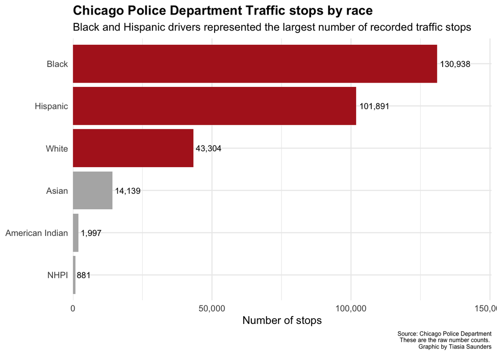

```r
## creating ggplot of solely race raw counts, so I can compare to the per capita
race_CPD_24 <- race_CPD_24 |>
  arrange(desc(n)) |>
  mutate(
    highlight = if_else(row_number() <= 3, "Top 3", "Other"),
    group = paste(race, highlight)
  )

ggplot(
  race_CPD_24,
  aes(
    x = reorder(race, n),
     y = n,
    fill = highlight
    )
) +
  geom_col() +

  geom_text(
    aes(label = comma(n)),
    hjust = -0.1,
    size = 3
  ) +

  coord_flip() +

  scale_fill_manual(
    values = c(
      "Top 3" = "#B22222",
      "Other" = "gray70"
    )
  ) +

  scale_y_continuous(
    labels = comma,
    expand = expansion(mult = c(0, .15))
  ) +

  labs(
    title = "Chicago Police Department Traffic stops by race",
    subtitle = "Black and Hispanic drivers represented the largest number of recorded traffic stops",
    x = NULL,
    y = "Number of stops",
    caption = "Source: Chicago Police Department\n These are the raw number counts. \n Graphic by Tiasia Saunders",
    plot_caption = 8
  ) +

  theme_minimal() +
  theme(
    legend.position = "none",
    plot.title = element_text(face = "bold"),
    plot.caption = element_text(size = 6)
  )
```

- This graphic is the raw counts of CPD traffic stops and it shows that Black and Hispanic drivers represented the largest number of recorded traffic stops in 2024, with Black drivers being stopped 130,938 times and Hispanic drivers being stopped 101,891 times. White drivers were the third most stopped group with 43,304 stops. The other racial groups had significantly fewer stops compared to these three groups.
- This graphic does not account for the population size of each racial group in Chicago, so it does not provide insight into the per capita rates of traffic.

#### Per capita Calculations to get a true reflection of the data, I need to account for population size when looking at the number of stops by race.

```r
### trying to bring in Chicago population data to be able to account for the per capita rates, will be able to do this for race and not gender since the census data doesn't include that

## bringing in Chicago population data to be able to calculate the per capita rates, changing from percentages to raw counts

chicago_demo <- tribble(
  ~race, ~population_pct,
  "White", 32.1,
  "Black", 27.9,
  "Hispanic", 29.7,
  "Asian", 7.3,
  "AIAN", 1.1,
  "NHPI", 0.1
)

total_pop <- 2746388
## so round is taking the results and rounding them to the nearest whole number so I won't have decimals in my new population column
chicago_demo_counts <- chicago_demo |>
  mutate(
    population = round(total_pop * (population_pct / 100))
  )

chicago_demo_counts
```

```
## # A tibble: 6 × 3
##   race     population_pct population
##   <chr>             <dbl>      <dbl>
## 1 White              32.1     881591
## 2 Black              27.9     766242
## 3 Hispanic           29.7     815677
## 4 Asian               7.3     200486
## 5 AIAN                1.1      30210
## 6 NHPI                0.1       2746
```

```r
## calculating for the per_capita rates of traffic stops by race in Chicago

## so first would join chicago_demo_counts to the race_CPD_24 by the column race, and then I would create a new column called per_capita_rate, which would be the number of stops

chicago_race_per_capita <- race_CPD_24 |>
  left_join(
    chicago_demo_counts,
     by = "race"
  ) |>
  mutate(
    stops_per_100k = round((n / population) * 100000)
  ) |>

arrange(desc(stops_per_100k)) |>

## creating the columns that will be highlighted in the graphic
mutate(
    highlight = ifelse(row_number() <= 3,
                       "Top 3",
                       "Other"))
```

```r
race_CPD_24 <- race_CPD_24 |>
  mutate(
    race = recode(
      race,
      "American Indian" = "AIAN"
    )
  )
```

```
## Ignoring unknown labels:
## • plot_caption : "8"
```

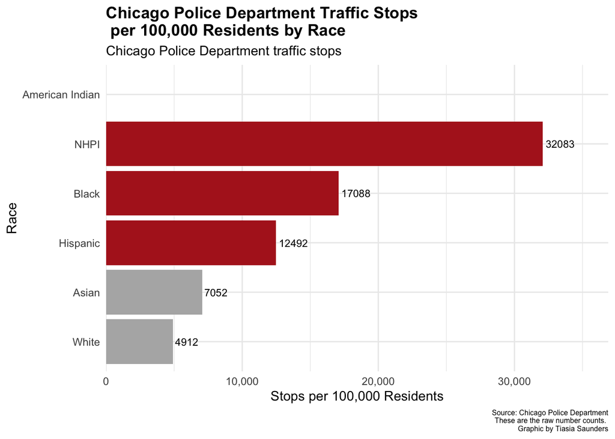

```r
## now graphing this

ggplot(
  chicago_race_per_capita,

  # reorder() sorts bars from highest to lowest
  aes(
    x = reorder(race, stops_per_100k),
    y = stops_per_100k,
    fill = highlight
  )
) +


  geom_col() +

  geom_text(
    aes(label = round(stops_per_100k, 1)),
    hjust = -0.1,
    size = 3
  ) +


  # flipping chart horizontally for easier reading
  coord_flip() +
  scale_fill_manual(
    values = c(
      "Top 3" = "#B22222",
      "Other" = "gray70"
    )
  ) +

   scale_y_continuous(
    labels = comma,
    expand = expansion(mult = c(0, .15))
  ) +


  labs(
    title = "Chicago Police Department Traffic Stops\n per 100,000 Residents by Race",
    subtitle = "Chicago Police Department traffic stops",
    x = "Race",
    y = "Stops per 100,000 Residents",
     caption = "Source: Chicago Police Department\n These are the raw number counts. \n Graphic by Tiasia Saunders",
    plot_caption = 8
  ) +
  guides(fill = "none") +

  theme_minimal() +
  theme(
    legend.position = "none",
    plot.title = element_text(face = "bold"),
    plot.caption = element_text(size = 6)
  )
```

```r
## add a sub bar with the population percentage for each race, will do that in datawrapper
```

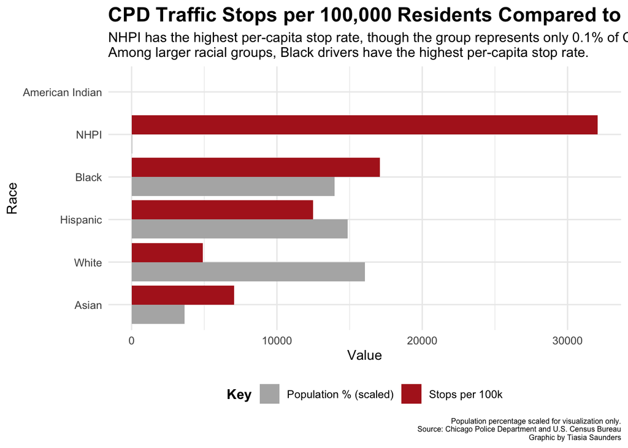

```r
## perfecting the graph to showcase the per capita rates with the population percentage to not overstate or mislead
## ADDING POPULATION COMPARISON LINE

chicago_per_plot <- chicago_race_per_capita |>
  mutate(
    pop_pct_scaled = population_pct * 500
  ) |>
  pivot_longer(
    cols = c(stops_per_100k, pop_pct_scaled),
    names_to = "metric",
    values_to = "value"
  )

chicago_per_plot <- ggplot(
  chicago_per_plot,
  aes(
    x = reorder(race, value),
    y = value,
    fill = metric
  )
) +

  geom_col(position = "dodge") +

  coord_flip() +

  scale_fill_manual(
    values = c(
      "stops_per_100k" = "#B22222",
      "pop_pct_scaled" = "gray70"
    ),
    labels = c(
      "Population % (scaled)",
      "Stops per 100k"
    )
  ) +

  labs(
    title = "CPD Traffic Stops per 100,000 Residents Compared to Population Share",

    subtitle = "NHPI has the highest per-capita stop rate, though the group represents only 0.1% of Chicago's population. \nAmong larger racial groups, Black drivers have the highest per-capita stop rate.",

    x = "Race",
    y = "Value",
    fill = "Key",

    caption = "Population percentage scaled for visualization only.\nSource: Chicago Police Department and U.S. Census Bureau\nGraphic by Tiasia Saunders"
  ) +


  theme_minimal() +

  theme(
  legend.position = "bottom",
  legend.title = element_text(face = "bold"),

  plot.title = element_text(face = "bold", size = 16),

  plot.caption = element_text(
    size = 6,
    hjust = 1
  )
)

chicago_per_plot
```

```
## Ignoring unknown labels:
## • plot_caption : "8"
```

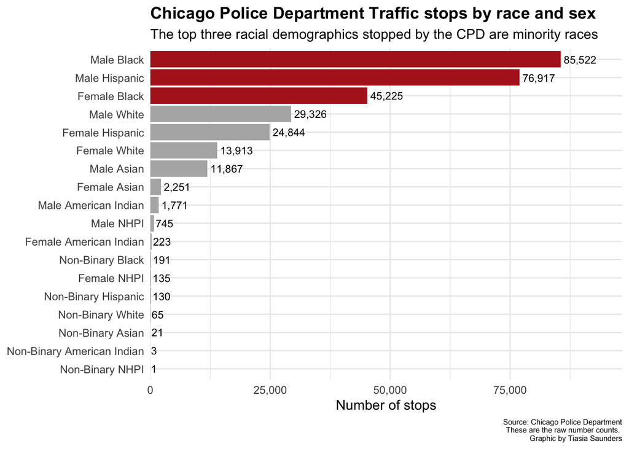

```r
## could not find gender and racial breakdown data for Chicago, so have to go with the raw counts instead

gender_race_CPD_24 <- gender_race_CPD_24 |>
  arrange(desc(n)) |>
  mutate(
    highlight = if_else(row_number() <= 3, "Top 3", "Other"),
    group = paste(sex, race)
  )

ggplot(
  gender_race_CPD_24,
  aes(
    x = reorder(group, n),
    y = n,
    fill = highlight
  )
) +
  geom_col() +

  geom_text(
    aes(label = comma(n)),
    hjust = -0.1,
    size = 3
  ) +

  coord_flip() +

  scale_fill_manual(
    values = c(
      "Top 3" = "#B22222",
      "Other" = "gray70"
    )
  ) +

  scale_y_continuous(
    labels = comma,
    expand = expansion(mult = c(0, .15))
  ) +

  labs(
    title = "Chicago Police Department Traffic stops by race and sex",
    subtitle = "The top three racial demographics stopped by the CPD are minority races",
    x = NULL,
    y = "Number of stops",
    caption = "Source: Chicago Police Department\n These are the raw number counts. \n Graphic by Tiasia Saunders",
    plot_caption = 8
  ) +
    guides(fill = "none") +

  theme_minimal() +
  theme(
    legend.position = "none",
    plot.title = element_text(face = "bold"),
    plot.caption = element_text(size = 6)
  )
```

- In 2024, there were 206,148 men who were involved in a CPD traffic stop, while 86,591 women were stopped, and 4ll non-binary people were stopped.
- As for race, in descending order Black people were stopped 130,938 times, followed by Hispanic/ Latino with 101,891 stops, and then white people were stopped 43,304 times.
- When broken down by gender and race, it was found that the top three gender/racial demographics who were stopped by CPD in 2024 were Black men with 85,522 stops, Hispanic men with 76,917 stops, and Black women with 45,225 stops.
  - These are just the raw counts, and I couldn’t find Chicago gender/racial breakdown population data, so I would not be able to calculate the per capita rates for these demographics, but it is still important to note that the top three demographics stopped by the CPD are minority.

```r
## going to do code of datestop time and duration, then make graphic showing the timeline
timeline_monthly <- traffic_CPD_24 |>
  mutate(month = floor_date(as.Date(datestop), "month")) |>
  count(month)

max_stops <- max(timeline_monthly$n)

c_timeline_plot <- ggplot(timeline_monthly, aes(x = month, y = n)) +
  geom_line(linewidth = 1) +
  geom_point(size = 2) +

  geom_vline(
    xintercept = as.Date("2024-03-21"),
    linetype = "dashed",
    color = "red"
  ) +
  annotate(
    "label",
    x = as.Date("2024-03-21"),
    y = max_stops * 0.9,
    label = "Dexter Reed fatal\nshooting incident",
    size = 7
  ) +

  geom_vline(
    xintercept = as.Date("2024-08-21"),
    linetype = "dashed",
    color = "red"
  ) +
  annotate(
    "label",
    x = as.Date("2024-08-21"),
    y = max_stops * 0.75,
    label = "Injustice Watch investigation:\nNearly 200,000 undocumented arrests",
    size = 7
  ) +

  scale_x_date(
    date_breaks = "1 month",
    date_labels = "%b"
  ) +
  scale_y_continuous(
    labels = scales::comma
  ) +
  labs(
    title = "Chicago Police Department traffic stops by month, 2024",
    x = NULL,
    y = "Number of stops",
    caption = "Source: Chicago Police Department, WWTW News, Injustice Watch\nGraphic by Tiasia Saunders"
  ) +
  theme_minimal() +
  theme(
    panel.grid.minor = element_blank(),
    axis.text.x = element_text(angle = 45, hjust = 1),
    plot.title = element_text(face = "bold", size = 20),
    plot.caption = element_text(hjust = 1, size = 6, color = "gray40")
  )
```

```r
traffic_CPD_24 <- traffic_CPD_24 |>
  mutate(
    city_i = str_remove_all(city_i, "[^A-Za-z ]"),
    city_i = str_squish(city_i)
  ) |>
  filter(
    !is.na(city_i),
    city_i != ""
  )
```

```r
city_race_table <- traffic_CPD_24 |>
  count(city_i, race) |>
  pivot_wider(
    names_from = race,
    values_from = n,
    values_fill = 0
  )

datatable(
  city_race_table,
  options = list(
    pageLength = 10,
    scrollX = TRUE
  ),
  caption = "Traffic stop counts by city and race"
)
```

|  | city_i | White | Black | Hispanic | Asian | American Indian | NHPI |
| --- | --- | --- | --- | --- | --- | --- | --- |
| 1 | AARLINGTON HEIGHTS | 1 | 0 | 0 | 0 | 0 | 0 |
| 2 | AAUSTINTOWN | 0 | 1 | 0 | 0 | 0 | 0 |
| 3 | ABBY | 0 | 1 | 0 | 0 | 0 | 0 |
| 4 | ABERDEAN | 0 | 1 | 0 | 0 | 0 | 0 |
| 5 | ABERDEEN | 1 | 0 | 2 | 0 | 0 | 0 |
| 6 | ABERDEEN PROVING | 0 | 1 | 0 | 0 | 0 | 0 |
| 7 | ABIA | 0 | 1 | 0 | 0 | 0 | 0 |
| 8 | ABQ | 0 | 1 | 0 | 0 | 0 | 0 |
| 9 | ACCORD | 0 | 0 | 1 | 0 | 0 | 0 |
| 10 | ACCORQUIN | 0 | 1 | 0 | 0 | 0 | 0 |

[output cut: 4994 more lines]

```r
## trying to see if mini bar charts would work

# Create monthly stop counts by race
month_CPD_race_counts <- traffic_CPD_24 |>

  # Create month labels from date column
  mutate(
    month = lubridate::month(datestop, label = TRUE)
  ) |>

  # Count stops by month and race
  count(month, race, name = "stops") |>

  # Keep months in calendar order
  mutate(
    month = factor(
      month,
      levels = c(
        "Jan", "Feb", "Mar", "Apr",
        "May", "Jun", "Jul", "Aug",
        "Sep", "Oct", "Nov", "Dec"
      )
    )
  ) |>

  # Sort data nicely
  arrange(race, month)

# View table
month_CPD_race_counts
```

```
## # A tibble: 72 × 3
##    month race            stops
##    <ord> <chr>           <int>
##  1 Jan   American Indian   282
##  2 Feb   American Indian   201
##  3 Mar   American Indian   207
##  4 Apr   American Indian   160
##  5 May   American Indian   117
##  6 Jun   American Indian   127
##  7 Jul   American Indian   145
##  8 Aug   American Indian   129
##  9 Sep   American Indian   144
## 10 Oct   American Indian   164
## # ℹ 62 more rows
```

```r
# Export for DataWrapper
write.csv(
  month_CPD_race_counts,
  "month_race_counts.csv",
  row.names = FALSE
)
```

- Created this to be able to compare CPD traffic stops across race throughout each month.

```r
# make sure month is ordered + shortened properly
month_CPD_race_counts <- month_CPD_race_counts |>
  mutate(
    month = factor(
      month,
      levels = c(
        "Jan","Feb","Mar","Apr","May","Jun",
        "Jul","Aug","Sep","Oct","Nov","Dec"
      )
    )
  )

p <- ggplot(
  month_CPD_race_counts,

  aes(
    x = month,
    y = stops,
    group = race,
    color = race,

    text = paste(
      "Race:", race,
      "<br>Month:", month,
      "<br>Stops:", comma(stops)
    )
  )
) +

  geom_line(linewidth = 1) +

  geom_point(size = 2) +

  facet_wrap(
    ~ race,
    scales = "fixed",
    ncol = 3   # makes panels smaller + more DataWrapper-like
  ) +

  labs(
    title = "CPD Monthly Traffic Stops by Race",
    x = NULL,
    y = "Number of Stops"
  ) +

  theme_minimal(base_size = 11) +

  theme(
    legend.position = "none",

    panel.grid.minor = element_blank(),

    strip.text = element_text(face = "bold"),

    axis.text.x = element_text(
      angle = 45,
      hjust = 1,
      vjust = 1
    ),

    plot.title = element_text(face = "bold")
  )

ggplotly(p, tooltip = "text")
```

[interactive chart not shown]

```r
## looking at vehicle make and model, the ones most likely to be stopped

vehicle_make_race <- traffic_CPD_24 |>
  count(vehmake, race) |>
  pivot_wider(
    names_from = race,
    values_from = n,
    values_fill = 0
  )


vehicle_make_race
```

```
## # A tibble: 766 × 7
##    vehmake                    Asian Black Hispanic White `American Indian`  NHPI
##    <chr>                      <int> <int>    <int> <int>             <int> <int>
##  1 (HOMEMADE MOTORCYCLE, MOP…     1     5       12     1                 0     0
##  2 (HOMEMADE TRAILER)             0     0        1     0                 0     0
##  3 (OBSOLETE VMA CODE FOR FO…     0     0        1     0                 0     0
##  4 (UNLISTED CONSTRUCTION EQ…     0     1        0     0                 0     0
##  5 (UNLISTED MAKE)                0     0        3     1                 0     0
##  6 (UNLISTED MANUFACTURER)        1     1        0     0                 0     0
##  7 ACADIAN (GM OF CANADA)         0     1        1     0                 0     0
##  8 ACADIAN (GM OF CANADA)/CA…     0     0        1     1                 0     0
##  9 ACURA                         59   403      781   164                 7     4
## 10 ACURA (DIV. OF AMERICAN H…   197   872     1774   526                17     8
## # ℹ 756 more rows
```

```r
DT::datatable(
  vehicle_make_race,
  caption = "Traffic stops by vehicle make and driver race",
  filter = "top",
  rownames = FALSE,
  options = list(
    pageLength = 25,
    scrollX = TRUE
  )
)
```

| vehmake | Asian | Black | Hispanic | White | American Indian | NHPI |
| --- | --- | --- | --- | --- | --- | --- |
| (HOMEMADE MOTORCYCLE, MOPED.ETC.) | 1 | 5 | 12 | 1 | 0 | 0 |
| (HOMEMADE TRAILER) | 0 | 0 | 1 | 0 | 0 | 0 |
| (OBSOLETE VMA CODE FOR FORD GOLDINE CAMPER) | 0 | 0 | 1 | 0 | 0 | 0 |
| (UNLISTED CONSTRUCTION EQUIPMENT MAKE) | 0 | 1 | 0 | 0 | 0 | 0 |
| (UNLISTED MAKE) | 0 | 0 | 3 | 1 | 0 | 0 |
| (UNLISTED MANUFACTURER) | 1 | 1 | 0 | 0 | 0 | 0 |
| ACADIAN (GM OF CANADA) | 0 | 1 | 1 | 0 | 0 | 0 |
| ACADIAN (GM OF CANADA)/CANSO SERIES) | 0 | 0 | 1 | 1 | 0 | 0 |
| ACURA | 59 | 403 | 781 | 164 | 7 | 4 |
| ACURA (DIV. OF AMERICAN HONDA MOTOR CO.) | 197 | 872 | 1774 | 526 | 17 | 8 |

[output cut: 756 more lines]

- So, we could just look at the top three Chevrolet cars have been stopped for Black and Hispanic the most, followed by white (its almost 10,000 less then their Black counterpart), and then Asian, which is only in the hundreds.
- The highest for white people is with the Toyota model at 6,685 stops, but even then black people were stopped more often in these cars at 7,707 stops, and Hispanic were stopped the most with 10,584 stops.

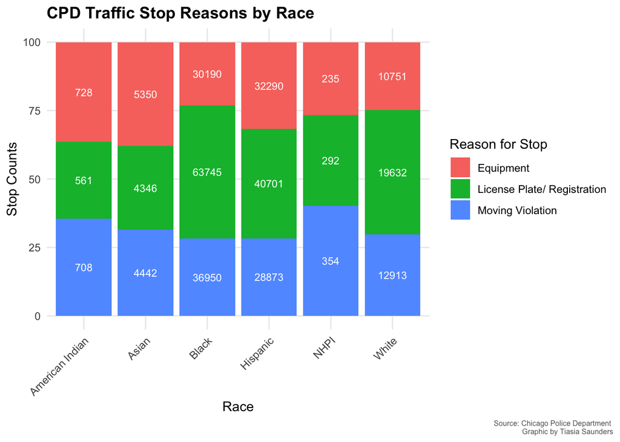

```r
## was going to put this in presentation, but I prefer the heatmap
ggplot(outcome_race, aes(x = race, y = percent, fill = reason_for_stop)) +

  geom_col() +

  # add count labels inside stacked bars
  geom_text(
    aes(label = n),
    position = position_stack(vjust = 0.5),
    size = 3,
    color = "white"
  ) +

  labs(
    title = "CPD Traffic Stop Reasons by Race",
    x = "Race",
    y = "Stop Counts",
    fill = "Reason for Stop",
    caption = "Source: Chicago Police Department \nGraphic by Tiasia Saunders"
  ) +

  theme_minimal() +

  theme(
    panel.grid.minor = element_blank(),
    axis.text.x = element_text(angle = 45, hjust = 1),
    plot.title = element_text(face = "bold"),
    plot.caption = element_text(hjust = 1, size = 6, color = "gray40"),
    plot.caption.position = "plot"
  )
```

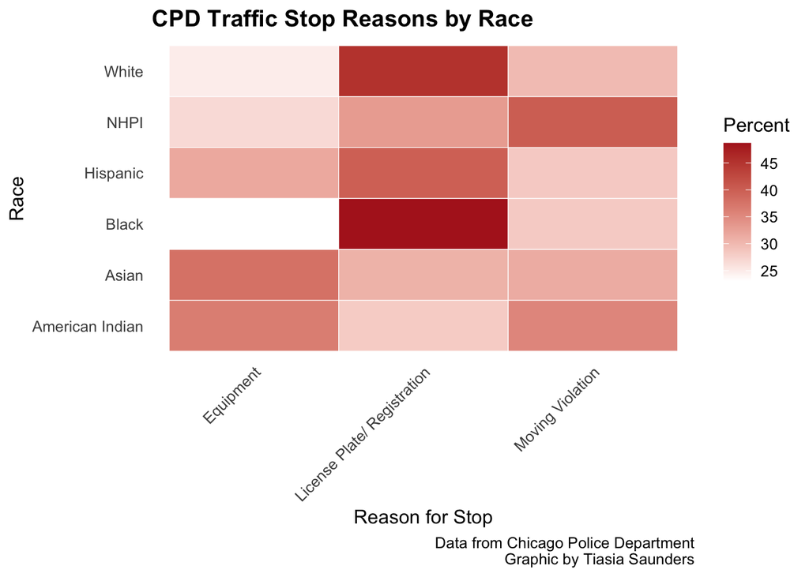

```r
 ggplot(
  outcome_race |>
    filter(!is.na(reason_for_stop)),

  aes(
    x = reason_for_stop,
    y = race,
    fill = percent,

    # what shows on hover
    text = paste(
      "Race:", race,
      "<br>Reason:", reason_for_stop,
      "<br>Percent:", round(percent, 1), "%"
    )
  )
) +

  geom_tile(color = "white") +

  scale_fill_gradient(low = "white", high = "#b22222") +


  labs(
    title = "CPD Traffic Stop Reasons by Race",
    x = "Reason for Stop",
    y = "Race",
    fill = "Percent",
    caption = "Data from Chicago Police Department\n Graphic by Tiasia Saunders"
  ) +

  theme_minimal(base_size = 12) +

  theme(
    axis.text.x = element_text(angle = 45, hjust = 1),
    panel.grid = element_blank(),
    plot.title = element_text(face = "bold")
  )
```

```r
ggplotly(p, tooltip = "text")
```

[interactive chart not shown]

```r
search_race <- traffic_CPD_24 |>
  group_by(race) |>
  summarise(
    total_stops = n(),
    searches = sum(vehsrchcond == TRUE, na.rm = TRUE),
    search_rate = searches / total_stops * 100
  )
```

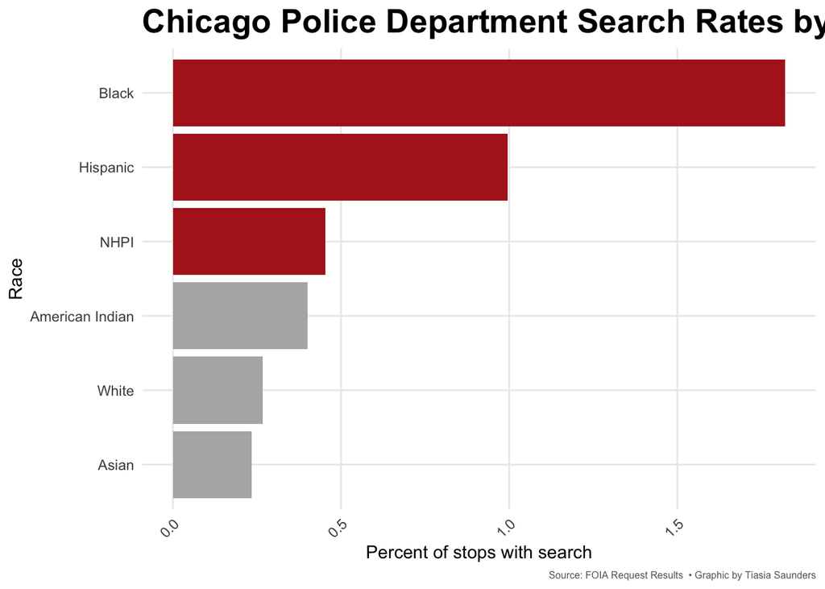

```r
search_race <- search_race |>
  arrange(desc(search_rate)) |>
  mutate(
    highlight = if_else(row_number() <= 3, "Top 3", "Other")
  )

 ggplot(search_race, aes(
  x = reorder(race, search_rate),
  y = search_rate,
  fill = highlight
)) +

  geom_col() +

  coord_flip() +

  scale_fill_manual(
    values = c(
      "Top 3" = "#B22222",
      "Other" = "gray70"
    )
  ) +

  guides(fill = "none") +

  labs(
    title = "Chicago Police Department Search Rates by Race After Traffic Stops",
    x = "Race",
    y = "Percent of stops with search",
    caption = "Source: FOIA Request Results  • Graphic by Tiasia Saunders"
  ) +

  theme_minimal() +
  theme(
    panel.grid.minor = element_blank(),
    axis.text.x = element_text(angle = 45, hjust = 1),
    plot.title = element_text(face = "bold", size=20),
    plot.caption = element_text(
      hjust = 1,
      size = 6,
      color = "gray40"
    ),
    plot.caption.position = "plot"
  )
```

```r
p <- ggplot(
  chicago_race_per_capita |>
    filter(!is.na(stops_per_100k)),

  aes(
    x = reorder(race, stops_per_100k),
    y = stops_per_100k,

    # hover info
    text = paste0(
      "Race: ", race,
      "<br>Per 100k stops: ", comma(round(stops_per_100k, 1)),
      "<br>Population share: ", population_pct, "%"
    )
  )
) +

  geom_point(size = 5, color = "#B22222") +

  coord_flip() +

  labs(
    title = "CPD Traffic Stops per 100,000 Residents by Race",
    x = "Race",
    y = "Stops per 100,000 Residents"
  ) +

  theme_minimal(base_size = 12) +

  theme(
    panel.grid.minor = element_blank(),
    plot.title = element_text(face = "bold")
  )

ggplotly(p, tooltip = "text")
```

[interactive chart not shown]

#### Preliminary Data Analysis With the Other Illinois Law Enforcement Agencies for 2024

```r
agency_traffic <- traffic_24 |>
  count(agency_name, race, name = "total_stops") |>
  arrange(desc(total_stops)) |>

pivot_wider(
    names_from = race,
    values_from = total_stops,
    values_fill = 0
  )
```

- There are 786 other law enforcement agencies in the traffic_2024 data.

```r
## ADDING DT OF THE ABOVE DATA

datatable(
  agency_traffic,
  options = list(
    pageLength = 10,
    autoWidth = TRUE,
    order = list(list(1, "desc"))
  ),
  caption = "Illinois Traffic Stops by Agency and Race"
)
```

|  | agency_name | White | Black | Hispanic | Asian | American Indian | NHPI |
| --- | --- | --- | --- | --- | --- | --- | --- |
| 1 | ILLINOIS STATE POLICE | 144943 | 68012 | 29373 | 7181 | 1157 | 501 |
| 2 | COOK COUNTY SHERIFF | 18744 | 16008 | 16523 | 4110 | 465 | 245 |
| 3 | WHEELING POLICE | 10844 | 1042 | 2924 | 1644 | 76 | 78 |
| 4 | PALATINE POLICE | 10765 | 1394 | 5323 | 1701 | 77 | 54 |
| 5 | SCHAUMBURG POLICE | 10723 | 2524 | 6336 | 4069 | 156 | 108 |
| 6 | AURORA POLICE | 4260 | 3713 | 8892 | 622 | 143 | 27 |
| 7 | EVERGREEN PARK POLICE | 4349 | 8056 | 1238 | 82 | 38 | 6 |
| 8 | NAPERVILLE POLICE | 7603 | 2970 | 2217 | 1975 | 46 | 6 |
| 9 | LOMBARD POLICE | 7379 | 2254 | 2709 | 1636 | 16 | 11 |
| 10 | BLOOMINGTON POLICE | 7337 | 2946 | 473 | 191 | 91 | 10 |

[output cut: 776 more lines]

```r
gender_traffic_24 <- traffic_24 |>
  count(sex, race) |>
  arrange(desc(n))

gender_traffic_24
```

```
##            sex            race      n
##         <char>          <char>  <int>
##  1:       Male           White 583079
##  2:     Female           White 371651
##  3:       Male        Hispanic 236865
##  4:       Male           Black 229857
##  5:     Female           Black 149561
##  6:     Female        Hispanic  99571
##  7:       Male           Asian  49568
##  8:     Female           Asian  20789
##  9:       Male American Indian   6036
## 10:       Male            NHPI   3203
## 11:     Female American Indian   1682
## 12:     Female            NHPI   1030
## 13:    Unknown           White    234
## 14: Non-Binary           Black     52
## 15: Non-Binary           White     40
## 16:    Unknown           Black     37
## 17:    Unknown        Hispanic     34
## 18: Non-Binary        Hispanic     15
## 19:    Unknown            NHPI      5
## 20:    Unknown           Asian      4
## 21: Non-Binary           Asian      2
## 22: Non-Binary            NHPI      2
## 23:    Unknown American Indian      2
## 24: Non-Binary American Indian      1
##            sex            race      n
##         <char>          <char>  <int>
```

```r
race_traffic_24 <- traffic_24 |>
  count(race) |>
  arrange(desc(n))

race_traffic_24
```

```
##               race      n
##             <char>  <int>
## 1:           White 955004
## 2:           Black 379507
## 3:        Hispanic 336485
## 4:           Asian  70363
## 5: American Indian   7721
## 6:            NHPI   4240
```

```r
gender_race_traffic_24 <- traffic_24 |>
  count(sex, race) |>
  arrange(desc(n))

gender_race_traffic_24
```

```
##            sex            race      n
##         <char>          <char>  <int>
##  1:       Male           White 583079
##  2:     Female           White 371651
##  3:       Male        Hispanic 236865
##  4:       Male           Black 229857
##  5:     Female           Black 149561
##  6:     Female        Hispanic  99571
##  7:       Male           Asian  49568
##  8:     Female           Asian  20789
##  9:       Male American Indian   6036
## 10:       Male            NHPI   3203
## 11:     Female American Indian   1682
## 12:     Female            NHPI   1030
## 13:    Unknown           White    234
## 14: Non-Binary           Black     52
## 15: Non-Binary           White     40
## 16:    Unknown           Black     37
## 17:    Unknown        Hispanic     34
## 18: Non-Binary        Hispanic     15
## 19:    Unknown            NHPI      5
## 20:    Unknown           Asian      4
## 21: Non-Binary           Asian      2
## 22: Non-Binary            NHPI      2
## 23:    Unknown American Indian      2
## 24: Non-Binary American Indian      1
##            sex            race      n
##         <char>          <char>  <int>
```

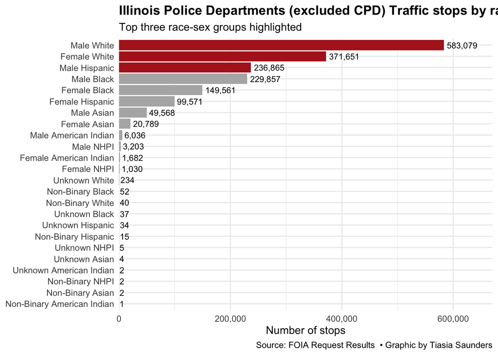

```r
## creating the bar chart

gender_race_traffic_24 <- gender_race_traffic_24 |>
  arrange(desc(n)) |>
  mutate(
    highlight = if_else(row_number() <= 3, "Top 3", "Other"),
    group = paste(sex, race)
  )

ggplot(
  gender_race_traffic_24,
  aes(
    x = reorder(group, n),
    y = n,
    fill = highlight
  )
) +
  geom_col() +

  geom_text(
    aes(label = comma(n)),
    hjust = -0.1,
    size = 3
  ) +

  coord_flip() +

  scale_fill_manual(
    values = c(
      "Top 3" = "#B22222",
      "Other" = "gray70"
    )
  ) +

  scale_y_continuous(
    labels = comma,
    expand = expansion(mult = c(0, .15))
  ) +

  labs(
    title = "Illinois Police Departments (excluded CPD) Traffic stops by race and sex",
    subtitle = "Top three race-sex groups highlighted",
    x = NULL,
    y = "Number of stops",
    caption = "Source: FOIA Request Results  • Graphic by Tiasia Saunders"
  ) +

  theme_minimal() +
  theme(
    legend.position = "none",
    plot.title = element_text(face = "bold")
  )
```

- So, when I am looking at this bar chart of all the other police departments traffic stops, I notice the top two are white males with 583,079 stops and white females with 371,651, and followed by Hispanic males with 236,865 stops. At first glance, it looks like white people are being stopped more than their minority counterparts, but as I hypothesized, I believe this is due to the population size of white people being very big in the state of Illinois.
- I am now going to account for racial per capita calculations to get a more robust picture of who is most likely to get stopped.

```r
## creating the timeline with annotations


timeline_traffic_monthly <- traffic_24 |>
  mutate(
    date_of_stop = as.Date(.data[["date_of_stop"]]),
    month = lubridate::floor_date(date_of_stop, unit = "month")
  ) |>
  count(month, name = "n") |>
  arrange(month)

max_stops <- max(timeline_traffic_monthly$n, na.rm = TRUE)

traffic_timeline_plot <- ggplot(timeline_traffic_monthly, aes(x = month, y = n)) +

  geom_line(linewidth = 1) +
  geom_point(size = 2) +

  geom_vline(
    xintercept = as.Date("2024-03-21"),
    linetype = "dashed",
    color = "red"
  ) +

  annotate(
    "label",
    x = as.Date("2024-03-21"),
    y = max_stops * 0.90,
    label = "Dexter Reed fatal\nshooting incident",
    size = 7
  ) +

  geom_vline(
    xintercept = as.Date("2024-06-14"),
    linetype = "dashed",
    color = "red"
  ) +

  annotate(
    "label",
    x = as.Date("2024-06-14"),
    y = max_stops * 0.98,
    label = "Snelling reports decline\nin traffic stops",
    size = 7,
    hjust = 0.5
  ) +

  geom_vline(
    xintercept = as.Date("2024-08-21"),
    linetype = "dashed",
    color = "red"
  ) +

  annotate(
    "label",
    x = as.Date("2024-08-21"),
    y = max_stops * 0.75,
    label = "Injustice Watch investigation:\n~200,000 undocumented arrests",
    size = 7,
    hjust = 0.5
  ) +

  scale_x_date(
    date_breaks = "1 month",
    date_labels = "%b"
  ) +

  scale_y_continuous(
    labels = scales::comma
  ) +

  labs(
    title = "Non-CPD Illinois law enforcement traffic stops by month, 2024",
    x = NULL,
    y = "Number of stops",
    caption = "Source: FOIA Request Results • Graphic by Tiasia Saunders"
  ) +

  theme_minimal() +

  theme(
    panel.grid.minor = element_blank(),
    axis.text.x = element_text(angle = 45, hjust = 1),
    plot.title = element_text(face = "bold", size = 20),
    plot.caption = element_text(size = 8, color = "gray40", hjust = 1)
  )

ggsave(
  filename = "traffic_timeline.png",
  plot = p,
  width = 10,
  height = 6,
  dpi = 300
)
```

#### Per capita Calculations to get a true reflection of the data, I need to account for population size when looking at the number of stops by race.

```r
## doing per capita for the other law enforcement agencies
per_capita_traffic_race <- traffic_24 |>
  count(race, name = "total_stops") |>
  left_join(census_2020_illinois, by = c("race" = "race_and_hispanic_origin")) |>
  mutate(
    stops_per_100k = round((total_stops / population_number) * 100000, 1)
  ) |>
  arrange(desc(stops_per_100k))

per_capita_traffic_race
```

```
##               race total_stops population_number stops_per_100k
##             <char>       <int>             <num>          <num>
## 1:            NHPI        4240              2959       143291.7
## 2:           Black      379507           1775612        21373.3
## 3:        Hispanic      336485           2337410        14395.6
## 4:           White      955004           7472751        12779.8
## 5:           Asian       70363            747280         9415.9
## 6: American Indian        7721                NA             NA
```

```r
per_capita_traffic_race <- per_capita_traffic_race |>
  mutate(
    population_pct = (population_number / sum(population_number)) * 100
  )

per_capita_traffic_race
```

```
##               race total_stops population_number stops_per_100k population_pct
##             <char>       <int>             <num>          <num>          <num>
## 1:            NHPI        4240              2959       143291.7             NA
## 2:           Black      379507           1775612        21373.3             NA
## 3:        Hispanic      336485           2337410        14395.6             NA
## 4:           White      955004           7472751        12779.8             NA
## 5:           Asian       70363            747280         9415.9             NA
## 6: American Indian        7721                NA             NA             NA
```

```r
census_2020_illinois <- census_2020_illinois|>
  mutate(
    race_and_hispanic_origin = recode(
      race_and_hispanic_origin,
      "American Indian and Alaska Native" = "AIAN"
    )
  )
```

[figure not shown]

```r
traffic_per_plot <- per_capita_traffic_race |>
  mutate(
    pop_pct_scaled = population_pct * 500
  ) |>
  pivot_longer(
    cols = c(stops_per_100k, pop_pct_scaled),
    names_to = "metric",
    values_to = "value"
  )

traffic_per_plot <- ggplot(
 traffic_per_plot,
  aes(
    x = reorder(race, value),
    y = value,
    fill = metric
  )
) +

  geom_col(position = "dodge") +

  coord_flip() +

  scale_fill_manual(
    values = c(
      "stops_per_100k" = "#B22222",
      "pop_pct_scaled" = "gray70"
    ),
    labels = c(
      "Population % (scaled)",
      "Stops per 100k"
    )
  ) +

  labs(
    title = "Illinois Traffic Stops per 100,000 Residents Compared to Population Share",

    subtitle = "NHPI had the highest per-capita stop rate among racial groups.\nAmong larger populations, Black drivers experienced the highest stop rates.",

    x = "Race",
    y = "Value",
    fill = "Key",

    caption = "Population percentage scaled for visualization only.\\nSource: Illinois traffic stop data and 2020 Census Bureau\\nGraphic by Tiasia Saunders"
  ) +

  theme_minimal() +

  theme(
  legend.position = "bottom",
  legend.title = element_text(face = "bold"),

  plot.title = element_text(face = "bold", size = 16),

  plot.caption = element_text(
    size = 6,
    hjust = 1
  )
)


traffic_per_plot
```

```r
ggsave(
  filename = "chicago_per_capita.png",
  plot = chicago_per_plot,
  width = 10,
  height = 8,
  dpi = 300,
  bg = "white"
)
search_race_illinois <- traffic_24 |>
  group_by(race) |>
  summarise(
    total_stops = n(),
    searches = sum(vehicle_search_conducted == TRUE, na.rm = TRUE),
    search_rate = searches / total_stops * 100
  )

search_race_illinois <- search_race_illinois |>
  arrange(desc(search_rate)) |>
  mutate(
    highlight = if_else(row_number() <= 3, "Top 3", "Other")
  )
```

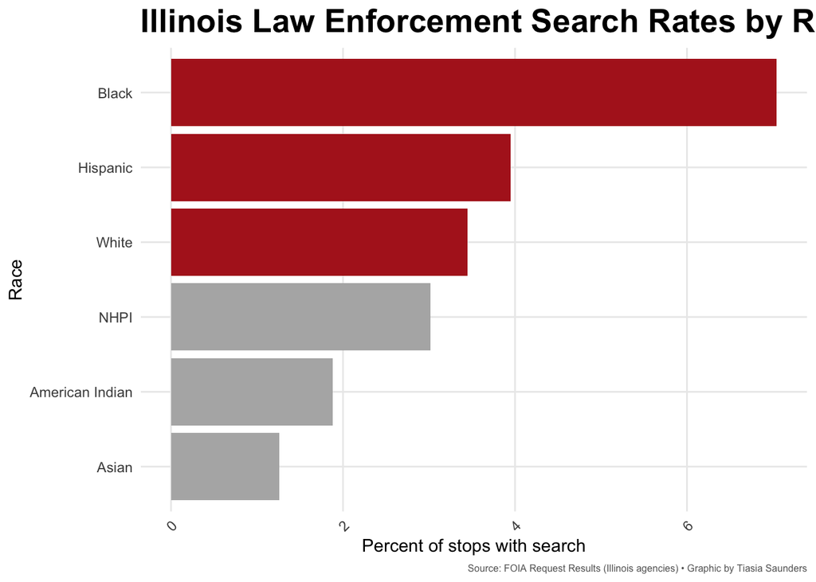

```r
 ggplot(search_race_illinois, aes(
  x = reorder(race, search_rate),
  y = search_rate,
  fill = highlight
)) +

  geom_col() +
  coord_flip() +

  scale_fill_manual(
    values = c(
      "Top 3" = "#B22222",
      "Other" = "gray70"
    )
  ) +

  guides(fill = "none") +

  labs(
    title = "Illinois Law Enforcement Search Rates by Race After Traffic Stops",
    x = "Race",
    y = "Percent of stops with search",
    caption = "Source: FOIA Request Results (Illinois agencies) • Graphic by Tiasia Saunders"
  ) +

  theme_minimal() +
  theme(
    panel.grid.minor = element_blank(),
    axis.text.x = element_text(angle = 45, hjust = 1),
    plot.title = element_text(face = "bold", size=20),
    plot.caption = element_text(
      hjust = 1,
      size = 6,
      color = "gray40"
    ),
    plot.caption.position = "plot"
  )
```

##### Veil of Darkness Element (Very Basic Level)

```r
## categorizing my time frames in my 2024 CPD traffic + other traffic datasets

traffic_CPD_24 <- traffic_CPD_24 |>
  mutate(
    stop_hour = hour(timestop),
    light_period = case_when(
      stop_hour >= 6 & stop_hour < 17 ~ "Daytime",
      stop_hour >= 22 | stop_hour < 4 ~ "Nighttime",
      TRUE ~ "Excluded transition hours"
    )
  )

traffic_CPD_24 |>
  count(light_period)
```

```
## # A tibble: 3 × 2
##   light_period                   n
##   <chr>                      <int>
## 1 Daytime                   128679
## 2 Excluded transition hours  92615
## 3 Nighttime                  71847
```

```r
traffic_CPD_24 <- traffic_CPD_24 |>
  mutate(
    race = recode(
      race,
      "American Indian" = "AIAN"
    )
  )

veil_race_CPD_24 <- traffic_CPD_24 |>
  filter(light_period != "Excluded transition hours") |>
  count(light_period, race) |>
  group_by(light_period) |>
  mutate(percent = n / sum(n) * 100) |>
  ungroup()

veil_race_CPD_24
```

```
## # A tibble: 12 × 4
##    light_period race         n percent
##    <chr>        <chr>    <int>   <dbl>
##  1 Daytime      AIAN       536   0.417
##  2 Daytime      Asian     4408   3.43
##  3 Daytime      Black    61807  48.0
##  4 Daytime      Hispanic 40745  31.7
##  5 Daytime      NHPI       353   0.274
##  6 Daytime      White    20830  16.2
##  7 Nighttime    AIAN       824   1.15
##  8 Nighttime    Asian     5440   7.57
##  9 Nighttime    Black    29432  41.0
## 10 Nighttime    Hispanic 26549  37.0
## 11 Nighttime    NHPI       250   0.348
## 12 Nighttime    White     9352  13.0
```

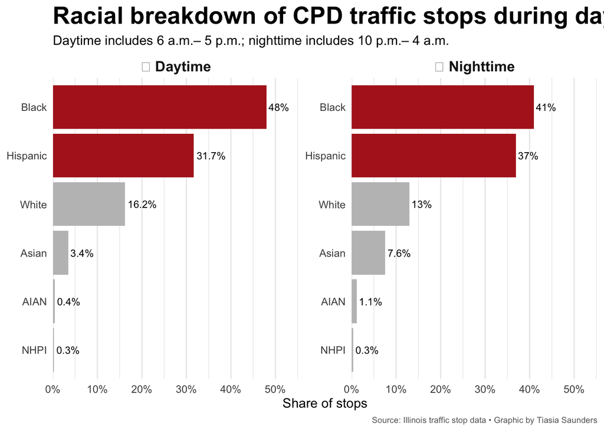

```r
veil_race_CPD_24 <- traffic_CPD_24 |>
  mutate(
    stop_hour = hour(timestop),
    light_period = case_when(
      stop_hour >= 6 & stop_hour < 17 ~ "☀ Daytime",
      stop_hour >= 22 | stop_hour < 4 ~ "☾ Nighttime",
      TRUE ~ "Excluded transition hours"
    )
  ) |>
  filter(light_period != "Excluded transition hours") |>
  count(light_period, race) |>
  group_by(light_period) |>
  mutate(
    percent = n / sum(n) * 100,
    race_ordered = reorder_within(race, percent, light_period),
    highlight = if_else(race %in% c("Black", "Hispanic"), "Highlighted", "Other")
  ) |>
  ungroup()

 ggplot(
  veil_race_CPD_24,
  aes(
    x = race_ordered,
    y = percent,
    fill = highlight
  )
) +
  geom_col() +
  geom_text(
    aes(label = paste0(round(percent, 1), "%")),
    hjust = -0.1,
    size = 3
  ) +
  coord_flip() +
  facet_wrap(~ light_period, scales = "free_y") +
  scale_x_reordered() +
  scale_fill_manual(
    values = c(
      "Highlighted" = "#B22222",
      "Other" = "gray75"
    )
  ) +
  scale_y_continuous(
    labels = label_percent(scale = 1),
    expand = expansion(mult = c(0, 0.15))
  ) +
  labs(
    title = "Racial breakdown of CPD traffic stops during daylight and nighttime hours",
    subtitle = "Daytime includes 6 a.m.– 5 p.m.; nighttime includes 10 p.m.– 4 a.m.",
    x = NULL,
    y = "Share of stops",
    caption = "Source: Illinois traffic stop data • Graphic by Tiasia Saunders"
  ) +
  theme_minimal() +
  theme(
    legend.position = "none",
    strip.text = element_text(face = "bold", size = 12),
    plot.title = element_text(face = "bold", size=20),
    plot.caption = element_text(size = 7, color = "gray40", hjust = 1),
    panel.grid.major.y = element_blank()
  )
```

```r
## calculating the daytime/nighttime for other traffic data

traffic_24 <- traffic_24 |>
  mutate(
    stop_hour = as.numeric(substr(time_of_stop, 1, 2)),
    light_period = case_when(
      stop_hour >= 6 & stop_hour < 17 ~ "Daytime",
      stop_hour >= 22 | stop_hour < 4 ~ "Nighttime",
      TRUE ~ "Excluded transition hours"
    )
  )

traffic_24 <- traffic_24 |>
  mutate(
   race = recode(
      race,
      "American Indian" = "AIAN"
    )
  )

veil_race_traffic_24 <- traffic_24 |>
  filter(light_period != "Excluded transition hours") |>
  count(light_period, driver_race) |>
  group_by(light_period) |>
  mutate(percent = n / sum(n) * 100) |>
  ungroup()

veil_race_traffic_24
```

```
## # A tibble: 12 × 4
##    light_period driver_race      n percent
##    <chr>              <int>  <int>   <dbl>
##  1 Daytime                1 495630  58.1
##  2 Daytime                2 160711  18.8
##  3 Daytime                3   3081   0.361
##  4 Daytime                4 157232  18.4
##  5 Daytime                5  34663   4.06
##  6 Daytime                6   2021   0.237
##  7 Nighttime              1 185069  46.8
##  8 Nighttime              2 107277  27.1
##  9 Nighttime              3   2380   0.602
## 10 Nighttime              4  82183  20.8
## 11 Nighttime              5  17528   4.43
## 12 Nighttime              6   1084   0.274
```

```r
## doing the same workflow for the general Illinois traffic stop data
traffic_24 <- traffic_24 |>
  mutate(
    stop_hour = as.numeric(substr(time_of_stop, 1, 2)),
    light_period = case_when(
      stop_hour >= 6 & stop_hour < 17 ~ " ☀ Daytime",
      stop_hour >= 22 | stop_hour < 4 ~ " ☾ Nighttime",
      TRUE ~ "Excluded transition hours"
    )
  )
```

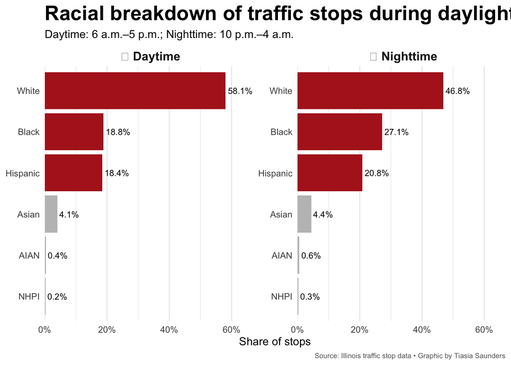

```r
veil_race <- traffic_24 |>
  filter(light_period != "Excluded transition hours") |>
  count(light_period, race) |>
  group_by(light_period) |>
  mutate(
    percent = n / sum(n) * 100,

    rank = rank(-percent),

    highlight = if_else(rank <= 3, "Top 3", "Other"),

    race_ordered = reorder_within(race, percent, light_period)
  ) |>
  ungroup()

 ggplot(veil_race, aes(x = race_ordered, y = percent, fill = highlight)) +
  geom_col() +

  geom_text(
    aes(label = paste0(round(percent, 1), "%")),
    hjust = -0.1,
    size = 3
  ) +

  coord_flip() +

  facet_wrap(~ light_period, scales = "free_y") +

  scale_x_reordered() +

  scale_fill_manual(
    values = c(
      "Top 3" = "#B22222",
      "Other" = "gray75"
    )
  ) +

  scale_y_continuous(
    labels = scales::label_percent(scale = 1),
    expand = expansion(mult = c(0, 0.15))
  ) +

  labs(
    title = "Racial breakdown of traffic stops during daylight and nighttime hours",
    subtitle = "Daytime: 6 a.m.–5 p.m.; Nighttime: 10 p.m.–4 a.m.",
    x = NULL,
    y = "Share of stops",
    caption = "Source: Illinois traffic stop data • Graphic by Tiasia Saunders"
  ) +

  theme_minimal() +

  theme(
    legend.position = "none",
    strip.text = element_text(face = "bold", size = 12),
    plot.title = element_text(face = "bold", size = 20),
    plot.caption = element_text(size = 7, color = "gray40", hjust = 1),
    panel.grid.major.y = element_blank()
  )
```

- During the day, Black drivers account for 18.8 percent of stops and at night they account for 27.1 percent of stops
  - That’s an increase of 8.3 percentage points, which is a 44 percent increase in the share of stops that Black drivers account for at night compared to the day
- On the other hand, white drivers fall from 58.1 percent of stops during the day to 46.8 percent at night
  - That’s a decrease of 11.3 percentage points, which is a 19.5 percent decrease in the share of stops that white drivers account for at night compared to the day

### How I could expand on this:

- I could create a more specific formula to account for actual sunset and sunrise times throughout the year by connecting weather app data, this would be more specific to the veil of darkness element and would be more accurate than just categorizing it by hours, but I think for the sake of this project and the time frame I have, this is sufficient enough to get a general idea of the trends. Should I attempt to do this?
- I could also look into the hit rate of drug searches by race and see if there are any disparities there, and then also look into the reason for stop and see if there are any racial disparities in the reason for stop and then also look at the hit rate of drug searches by reason for stop and see if there are any disparities there as well.

#### Next Steps (Before presentation):

- I plan to make an interactive map showcasing the amount of stops at different agencies locations and the racial breakdown of those stops, and then also make a graphic showing the top 10 most common vehicle makes that were stopped by CPD in 2024 and the racial breakdown of those stops.
- I will think of other potential graphics, but I think I’m good for the most part
- I will carefully look back through data analysis to ensure everything is correct before transitioning to webpage
- I plan to save these graphics (after looking back through code to make sure its correct) and then start to build my webpage for presentation
- I will be using Phoenix Code to create a html, css, and javascript webpage for presentation on Saturday
  - I want my end project to look really good so that I can add to portfolio and also so that I can share the results with the IPORAE members.